# Homework5-DataVis-ggplot

Ciara S

DUE: Thursday, March 25

#### Necessary items:

- **libraries:** tidyverse, ggsci, ggforce, patchwork, Hmisc
- **files:** bloom_df.csv, hw_task2_blank.png

Within RStudio you can directly edit these blocks of code and turn in your homework that way with your code and figures printed.  
I **HIGHLY** recommend getting your code to work in a normal R script then just copy and pasting the final code over to this document

**First: import libraries, set your working directory, and read in bloom_df**

```r
library(tidyverse)
library(ggforce)
library(ggsci)
library(patchwork)
library(Hmisc)
library(ggsignif)
library(data.table)
library(plotrix)
library(stats)

setwd('C:/Users/cnshe/Desktop/Grad_School/Class_Notes/Data_Science/Data_Science_For_Biology_II-Spring_21/Part.3_DataVisualization/1-ggplot') #change to match your ggplot directory

bloom_df <- read.csv('C:/Users/cnshe/Desktop/Grad_School/Class_Notes/Data_Science/Data_Science_For_Biology_II-Spring_21/Part.3_DataVisualization/1-ggplot/bloom_df.csv')
```

### bloom_df contents

- **taxa:** genus_species
- **genus**
- **species**
- **logbodysize**
- **trophic_position**
- **reg:** diadromous or non-diadromous

Let’s take a peak and look at the structure

```r
bloom_df[1:5,]
```

```
##                   taxa genus        species logbodysize trophic_position
## 1       Alosa_alabamae Alosa       alabamae    1.707570        0.4313638
## 2          Alosa_alosa Alosa          alosa    1.778151        0.5563025
## 3         Alosa_fallax Alosa         fallax    1.778151        0.5563025
## 4      Alosa_mediocris Alosa      mediocris    1.778151        0.6127839
## 5 Alosa_pseudoharengus Alosa pseudoharengus    1.602060        0.5440680
##          reg
## 1 diadromous
## 2 diadromous
## 3 diadromous
## 4 diadromous
## 5 diadromous
```

```r
str(bloom_df)
```

```
## 'data.frame':    50 obs. of  6 variables:
##  $ taxa            : chr  "Alosa_alabamae" "Alosa_alosa" "Alosa_fallax" "Alosa_mediocris" ...
##  $ genus           : chr  "Alosa" "Alosa" "Alosa" "Alosa" ...
##  $ species         : chr  "alabamae" "alosa" "fallax" "mediocris" ...
##  $ logbodysize     : num  1.71 1.78 1.78 1.78 1.6 ...
##  $ trophic_position: num  0.431 0.556 0.556 0.613 0.544 ...
##  $ reg             : chr  "diadromous" "diadromous" "diadromous" "diadromous" ...
```

### Graphical tasks

This next tasks are going to ask you to make a series of figures. For each one, I would like you to make all of them *look good*. Change the theme around, change the axis labels, etc. Additionally, each of these will use the **reg** column which has 2 factors. Change the color and/or shape of them both.

### Task 1: Continuous vs. continuous plot

Create two scatterplots of logbodysize vs. trophic_position grouped by reg

##### First plot:

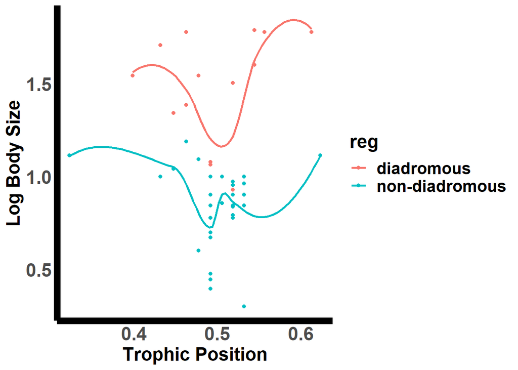

```r
ggplot(data=bloom_df,aes(x=trophic_position,y=logbodysize,color=reg)) +
  geom_point() +
  geom_smooth(method= "loess", se=FALSE, aes(trophic_position, logbodysize, color = reg), size = 1) +
  ylab("Log Body Size") +
  xlab("Trophic Position") +
  theme_classic() +
  theme(axis.title.x = element_text(face = "bold", size = 18),
        axis.title.y = element_text(face = "bold", size = 18),
        axis.text.x = element_text(face = "bold", size = 18),
        axis.text.y = element_text(face = "bold", size = 18),
        axis.line = element_line(colour = 'black', size = 3),
        axis.ticks = element_line(colour = "black", size = 3),
        plot.title = element_text(face = "bold", hjust = 0.5, size = 18),
        legend.text = element_text(face = "bold", size = 16),
        legend.title = element_text(face = "bold", size = 18))
```

```r
#plot 1.1
```

##### Second plot

- a single trend line for the whole model

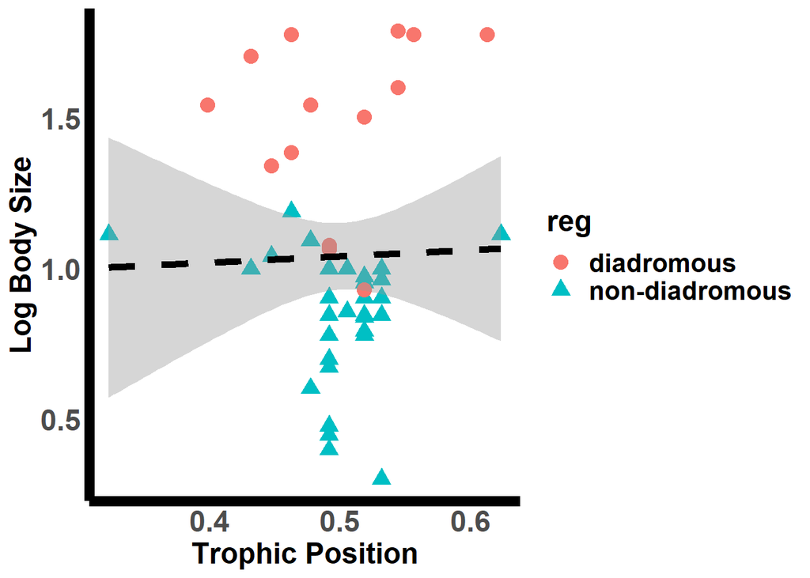

```r
ggplot(data=bloom_df,aes(x=trophic_position,y=logbodysize)) +
  geom_point(aes(colour=reg,shape=reg),size=4) +
  stat_smooth(method='lm',linetype='dashed',colour='black',size=2)+
  ylab("Log Body Size") +
  xlab("Trophic Position") +
  theme_classic() +
  theme(axis.title.x = element_text(face = "bold", size = 18),
        axis.title.y = element_text(face = "bold", size = 18),
        axis.text.x = element_text(face = "bold", size = 18),
        axis.text.y = element_text(face = "bold", size = 18),
        axis.line = element_line(colour = 'black', size = 3),
        axis.ticks = element_line(colour = "black", size = 3),
        plot.title = element_text(face = "bold", hjust = 0.5, size = 18),
        legend.text = element_text(face = "bold", size = 16),
        legend.title = element_text(face = "bold", size = 18))
```

```r
#plot 1.2
```

### Task 2: Continuous vs. categorical

##### The layout will be:

- 2 panels: trophic_position and logbodysize
- x axis: reg
- y axis: value of trophic_position and logbodysize

##### Create 4 plots:

- bar and error bars (mean and 95% conf. int.)
- point and error bars (mean and 95% conf. int.)
- box plots
- raw data + point and error bars (mean and 95% conf. int.)

All these plots should have the same general layout but change the type of plot to visualize the data.

**HINT:** logbodysize and trophic_position need to be turned into long format

```r
logBloom_df <- bloom_df %>%
  group_by(reg) %>%
  summarise(mean = mean(logbodysize, na.rm = TRUE), #log mean
            sd = sd(logbodysize, na.rm = TRUE), #log standard deviation
            n = n()) %>% #log count
  mutate(se = sd / sqrt(n), #log standard error
         ci = 1.96 * se) #log 95% confidence interval
logBloom_df$Measurement <- 'logbodysize'

trophicBloom_df <- bloom_df %>%
  group_by(reg) %>%
  summarise(mean = mean(trophic_position, na.rm = TRUE), #troph mean
            sd = sd(trophic_position, na.rm = TRUE), #troph standard deviation
            n = n()) %>% #troph count
  mutate(se = sd / sqrt(n), #troph standard error
         ci = 1.96*se) #troph 95% confidence interval
trophicBloom_df$Measurement <- 'trophic_position'

bloom_sum_df <- rbind(logBloom_df,trophicBloom_df)
bloom_sum_df
```

```
## # A tibble: 4 x 7
##   reg             mean     sd     n      se     ci Measurement
##   <chr>          <dbl>  <dbl> <int>   <dbl>  <dbl> <chr>
## 1 diadromous     1.51  0.290     15 0.0750  0.147  logbodysize
## 2 non-diadromous 0.842 0.207     35 0.0350  0.0686 logbodysize
## 3 diadromous     0.501 0.0567    15 0.0146  0.0287 trophic_position
## 4 non-diadromous 0.501 0.0443    35 0.00748 0.0147 trophic_position
```

##### Example layout:

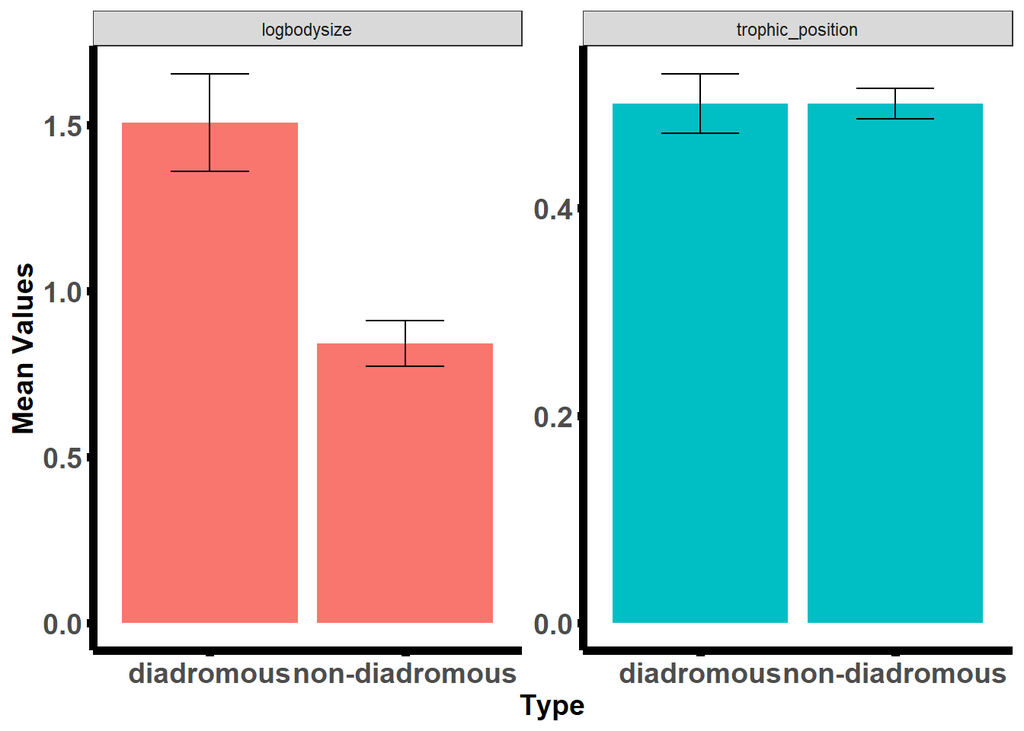

```r
ggplot(data=bloom_sum_df,aes(x=reg,y=mean,fill=Measurement)) +
  facet_wrap(~Measurement,nrow=1,scales = 'free') +
  geom_bar(stat='identity')+
  geom_errorbar(aes(ymin = mean - ci, ymax = mean + ci), width=0.4) +
  ylab("Mean Values") +
  xlab("Type") +
  theme_bw() +
  theme(legend.position = "none",
        legend.title = element_blank(),
        panel.border = element_blank(), panel.grid.major = element_blank(),
        panel.grid.minor = element_blank(),
        axis.title.x = element_text(face = "bold", size = 14),
        axis.title.y = element_text(face = "bold", size = 14),
        axis.text.x = element_text(face = "bold", size = 14),
        axis.text.y = element_text(face = "bold", size = 14),
        axis.line = element_line(colour = 'black', size = 2),
        axis.ticks = element_line(colour = "black", size = 2),
        plot.title = element_text(face = "bold", hjust = 0.5, size = 18))
```

```r
#plot 2.1
```

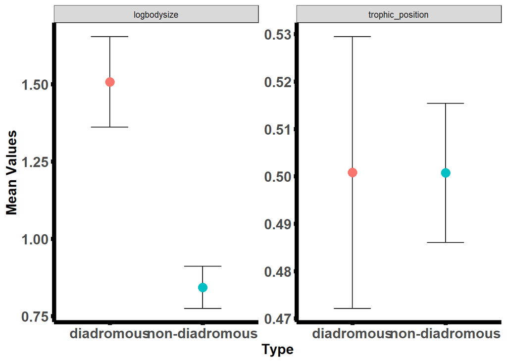

```r
ggplot(data=bloom_sum_df,aes(x=reg,y=mean,fill=Measurement)) +
  facet_wrap(~Measurement,nrow=1,scales = 'free') +
  geom_errorbar(aes(ymin = mean - ci, ymax = mean + ci), width=0.4) +
  geom_point(aes(color = reg), size=4) +
  ylab("Mean Values") +
  xlab("Type") +
  theme_bw() +
  theme(legend.position = "none",
        legend.title = element_blank(),
        panel.border = element_blank(), panel.grid.major = element_blank(),
        panel.grid.minor = element_blank(),
        axis.title.x = element_text(face = "bold", size = 14),
        axis.title.y = element_text(face = "bold", size = 14),
        axis.text.x = element_text(face = "bold", size = 14),
        axis.text.y = element_text(face = "bold", size = 14),
        axis.line = element_line(colour = 'black', size = 2),
        axis.ticks = element_line(colour = "black", size = 2),
        plot.title = element_text(face = "bold", hjust = 0.5, size = 18))
```

```r
#plot 2.2
```

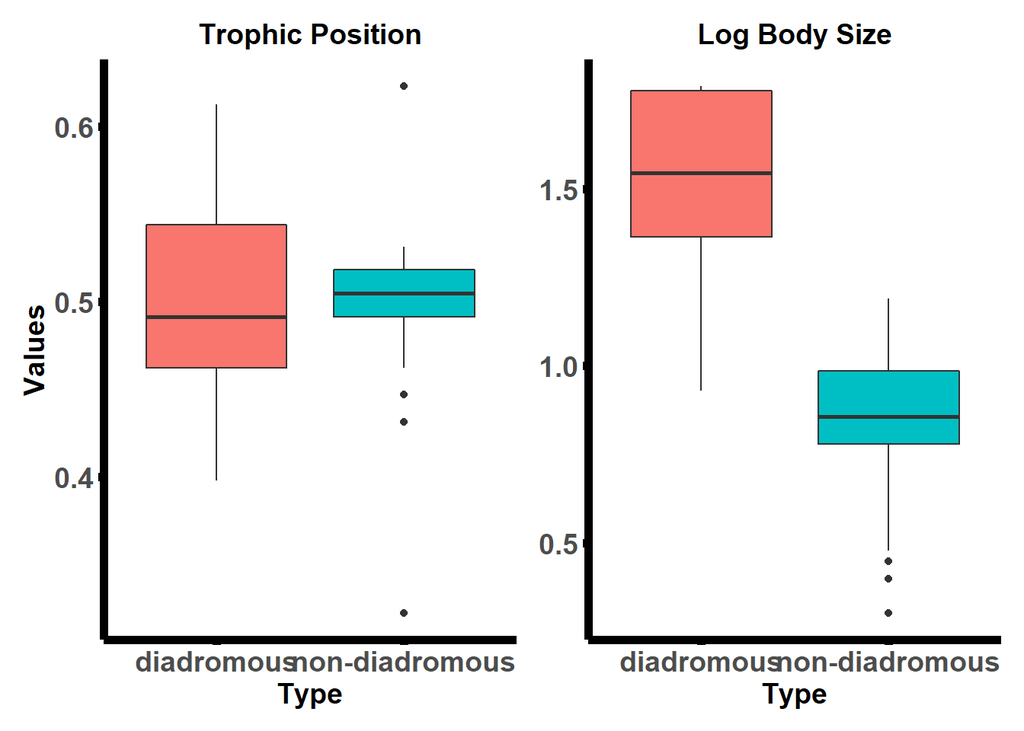

```r
ggplot(data=bloom_df,aes(x=reg,y=trophic_position,fill=reg)) +
  geom_boxplot() +
  ggtitle("Trophic Position")+
  ylab("Values") +
  xlab("Type") +
  theme_bw() +
  theme(legend.position = "none",
        legend.title = element_blank(),
        panel.border = element_blank(), panel.grid.major = element_blank(),
        panel.grid.minor = element_blank(),
        axis.title.x = element_text(face = "bold", size = 14),
        axis.title.y = element_text(face = "bold", size = 14),
        axis.text.x = element_text(face = "bold", size = 14),
        axis.text.y = element_text(face = "bold", size = 14),
        axis.line = element_line(colour = 'black', size = 2),
        axis.ticks = element_line(colour = "black", size = 2),
        plot.title = element_text(face = "bold", hjust = 0.5, size = 14)) +
  ggplot(data=bloom_df,aes(x=reg,y=logbodysize,fill=reg)) +
  geom_boxplot() +
  ggtitle("Log Body Size")+
  ylab(NULL) +
  xlab("Type") +
  theme_bw() +
  theme(legend.position = "none",
        legend.title = element_blank(),
        panel.border = element_blank(), panel.grid.major = element_blank(),
        panel.grid.minor = element_blank(),
        axis.title.x = element_text(face = "bold", size = 14),
        axis.title.y = element_text(face = "bold", size = 14),
        axis.text.x = element_text(face = "bold", size = 14),
        axis.text.y = element_text(face = "bold", size = 14),
        axis.line = element_line(colour = 'black', size = 2),
        axis.ticks = element_line(colour = "black", size = 2),
        plot.title = element_text(face = "bold", hjust = 0.5, size = 14))
```

```r
#plot 2.3
```

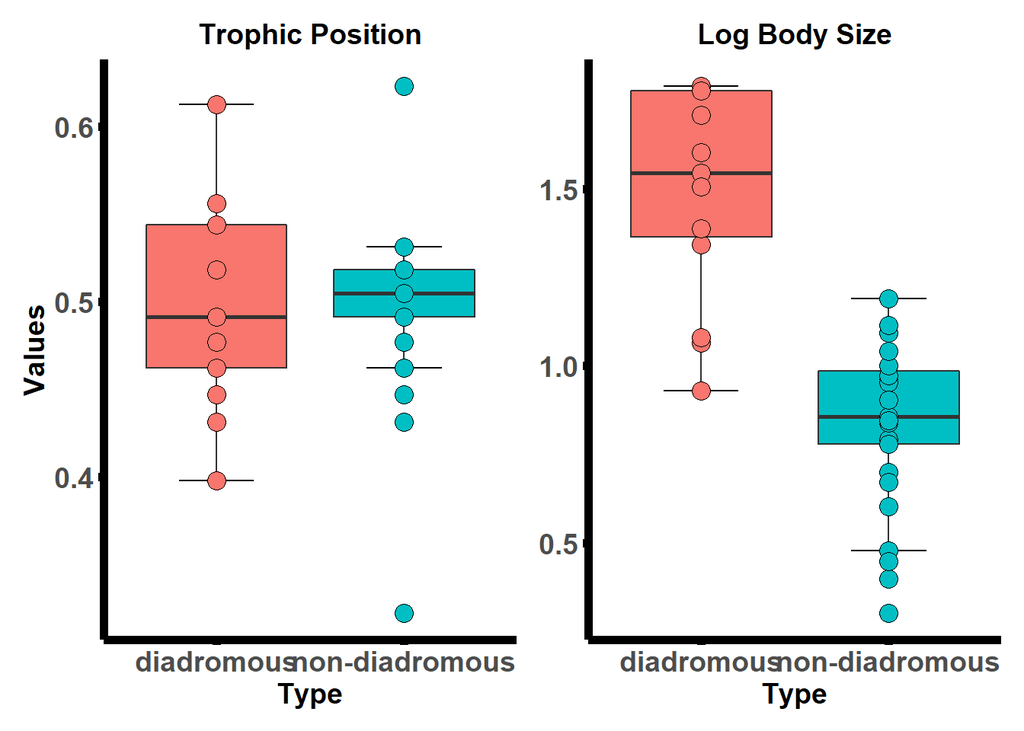

```r
ggplot(data=bloom_df,aes(x=reg,y=trophic_position,fill=reg)) +
  stat_boxplot(aes(reg, trophic_position), geom='errorbar', linetype=1, width=0.4) +
  geom_boxplot() +
  geom_point(aes(color = reg), pch = 21, color = "black", size=4) +
  ggtitle("Trophic Position")+
  ylab("Values") +
  xlab("Type") +
  theme_bw() +
  theme(legend.position = "none",
        legend.title = element_blank(),
        panel.border = element_blank(), panel.grid.major = element_blank(),
        panel.grid.minor = element_blank(),
        axis.title.x = element_text(face = "bold", size = 14),
        axis.title.y = element_text(face = "bold", size = 14),
        axis.text.x = element_text(face = "bold", size = 14),
        axis.text.y = element_text(face = "bold", size = 14),
        axis.line = element_line(colour = 'black', size = 2),
        axis.ticks = element_line(colour = "black", size = 2),
        plot.title = element_text(face = "bold", hjust = 0.5, size = 14)) +
  ggplot(data=bloom_df,aes(x=reg,y=logbodysize,fill=reg)) +
  stat_boxplot(aes(reg, logbodysize), geom='errorbar', linetype=1, width=0.4) +
  geom_boxplot()+
  geom_point(aes(color = reg), pch = 21, color = "black", size=4) +
  ggtitle("Log Body Size")+
  ylab(NULL) +
  xlab("Type") +
  theme_bw() +
  theme(legend.position = "none",
        legend.title = element_blank(),
        panel.border = element_blank(), panel.grid.major = element_blank(),
        panel.grid.minor = element_blank(),
        axis.title.x = element_text(face = "bold", size = 14),
        axis.title.y = element_text(face = "bold", size = 14),
        axis.text.x = element_text(face = "bold", size = 14),
        axis.text.y = element_text(face = "bold", size = 14),
        axis.line = element_line(colour = 'black', size = 2),
        axis.ticks = element_line(colour = "black", size = 2),
        plot.title = element_text(face = "bold", hjust = 0.5, size = 14))
```

```r
#plot 2.4
```

### Task 3: layering your plots

Make any two figures with the bloom_df! Can be something we’ve done or something completely different. Make one TERRIBLE figure and one GREAT figure.

Put them together using *patchwork* or *ggarrange*

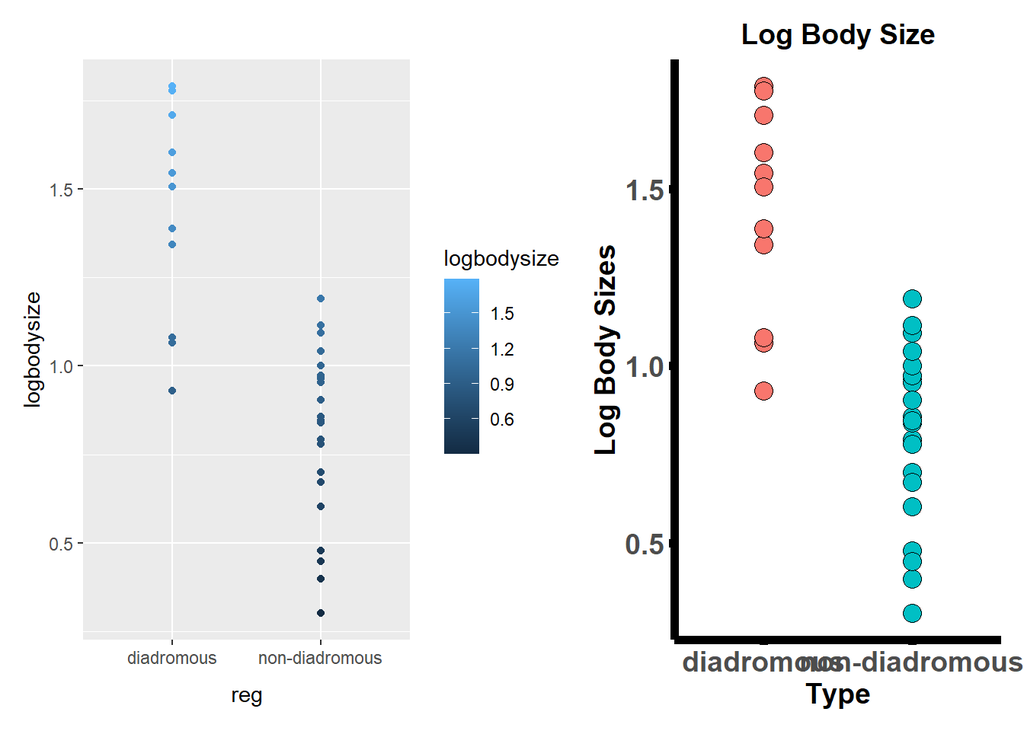

```r
#Bad plot
bad <- ggplot(data=bloom_df,aes(x=reg,y=logbodysize)) +
  geom_point(aes(color = logbodysize))

#Good plot
good <- ggplot(data=bloom_df,aes(x=reg,y=logbodysize,fill=reg)) +
  geom_point(aes(color = reg), pch = 21, color = "black", size=4) +
  ggtitle("Log Body Size")+
  ylab("Log Body Sizes") +
  xlab("Type") +
  theme_bw() +
  theme(legend.position = "none",
        legend.title = element_blank(),
        panel.border = element_blank(), panel.grid.major = element_blank(),
        panel.grid.minor = element_blank(),
        axis.title.x = element_text(face = "bold", size = 14),
        axis.title.y = element_text(face = "bold", size = 14),
        axis.text.x = element_text(face = "bold", size = 14),
        axis.text.y = element_text(face = "bold", size = 14),
        axis.line = element_line(colour = 'black', size = 2),
        axis.ticks = element_line(colour = "black", size = 2),
        plot.title = element_text(face = "bold", hjust = 0.5, size = 14))

bad+good
```

```r
#plot 3
```